If we take a look at the averages graph, we see that it primarily reflects the seasonal variation in temperature, that is, we see a pattern of increasing temperatures from winter to summer months and then a decrease as it moves into autumn and winter again, which is in line with what we would expect (single year/depth also have this pattern with some exceptions).

* Current month vs same month of the previous 30 years: This type of comparison is more indicative of long-term climate trends. If there is a general increase in temperatures over the years for a given month, it would suggest a warming trend. If we take a look at the four graphs generated in the examples, we can see that the last two, which show the average across all years with specific depth and all years for all depths, the temperature increases are consistent across all months (in the order of 0.4-0.6 degrees).

When looking at the second graph (specific year, all depths), we can also see how, except January and April, all months experience increases in temperature when compared to the same months 30 years before. When looking at the first graph (specific year and depth), the increase in temperature is more inconsistent (due to less data), but still 9 out of 12 months experience increases, with only two experiencing decreases likely due to short term variation. Still, in the long term and especially when taking all year averages we can see that for all months, all temperatures experienced a consistent increase over the last period of 30 years.

After this visual inspection of the temperature differences, we can tentatively conclude that there is a solid case for the central argument of climate change, that is, that GHG emissions increasing temperatures on earth. This increase in worldwide temperatures is also invariably affecting (negatively) marine ecosystems, with the average of marine temperatures being increased between an average of 0.4-0.6 degrees Celsius in the last 30 years (with variability when accounting for different years or depths).

With that being said, it is also important to note that strictly statistically speaking, we would have to perform some additional tests to check whether this difference is statistically significant or not. But since this is not what it is asked in the exercise we will not perform this analysis. We will assume, based on the visual inspection, that temperatures have indeed increased over the last period of 30 years based on the data we have (sea.deep dataframe).

**Projecting the future of seawater temperature: An ARIMA based approach**

```r
#build a library to project the future of seawater temperature at a certain temperature for
#the following years

library(forecast)
final_result1<- firstFinalResult

forecast_sarima <- function(data, column_name, depth_value=NULL) {
  # Exclude 'Mitjana anual' rows from the dataset
  data_filtered <- data[data$Month != "Mitjana anual", ]

  # Filter by depth if a specific depth is provided
  if (!is.null(depth_value)) {
    data_filtered <- data_filtered[data_filtered$Depth == depth_value, ]
  }

  # Create a mapping for the months
  month_mapping <- setNames(1:12, c("Gener", "Febrer", "Març", "Abril", "Maig", "Juny",
                                    "Juliol", "Agost", "Setembre", "Octubre", "Novembre", "Desembre"))

  # Replace month names with numeric values
  data_filtered$MonthNum <- month_mapping[as.character(data_filtered$Month)]

  # Create YearMonth variable
  data_filtered$YearMonth <- with(data_filtered, paste(Year_Current, MonthNum, sep = "-"))

  # Aggregate the specified column
  avg_data <- aggregate(data_filtered[[column_name]] ~ YearMonth, data = data_filtered, mean, na.rm = TRUE)

  # Extract Year and Month from YearMonth
  avg_data$Year <- as.numeric(sapply(strsplit(avg_data$YearMonth, "-"), `[`, 1))
  avg_data$Month <- as.numeric(sapply(strsplit(avg_data$YearMonth, "-"), `[`, 2))

  # Remove rows where Month is NA
  avg_data <- avg_data[!is.na(avg_data$Month), ]

  # Sort the data by Year and Month
  avg_data <- avg_data[order(avg_data$Year, avg_data$Month), ]

  # Create the time series object
  start_year <- min(avg_data$Year)
  start_month <- min(avg_data$Month[avg_data$Year == start_year])
  ts_data <- ts(avg_data[[2]], start = c(start_year, start_month), frequency = 12)

  # Fit a SARIMA model
  fit_model <- auto.arima(ts_data)

  # Calculate residuals
  residuals_data <- residuals(fit_model)

  # Forecast
  future_forecast <- forecast(fit_model, h = 50*12) # 50 years into the future

  # Plot the forecast
  plot(future_forecast)

  # Return the model, forecast, and residuals
  return(list(model = fit_model, forecast = future_forecast, residuals = residuals_data))
}
```

**Projecting the future of seawater temperature: Checking how well each forecast is fit**

```r
#Check how well each forecast is fit.
perform_diagnostics <- function(model, residuals_data, variable_name) {
  # TS Diagnostics Plot
  tsdiag(model)

  # Residuals Plot
  plot(residuals_data, main = paste("Residuals of", variable_name))
  abline(h = 0, col = "red")

  # ACF and PACF of Residuals
  acf(residuals_data, main = paste("ACF of", variable_name, "Residuals"))
  pacf(residuals_data, main = paste("PACF of", variable_name, "Residuals"))

  # Shapiro-Wilk Normality Test
  shapiro_test_result <- shapiro.test(residuals_data)
  print(paste("Shapiro-Wilk Test for", variable_name, ": p-value =", shapiro_test_result$p.value))
}
```

This R code is structured for two primary objectives: forecasting future sea water temperatures and conducting diagnostic checks on the forecasts. It utilizes the forecast package, which is widely recognized for its efficacy in time series analysis.

The first part of the code defines the forecast_sarima function. This function is designed to project future sea water temperatures based on the provided data. The function operates by filtering the dataset to exclude rows marked as ‘Mitjana anual’ and, if specified, narrows down the data to a particular depth. The months are then mapped to numeric values to facilitate the processing. A YearMonth variable is created for data aggregation purposes, followed by calculating the average value of the chosen column for each month. Subsequently, this aggregated data is transformed into a time series object, essential for the forecasting process.

The core of the function is fitting a Seasonal Autoregressive Integrated Moving Average (SARIMA) model using the auto.arima function. SARIMA models are particularly suited for data exhibiting seasonal trends, such as monthly temperature variations. The model is then used to forecast future values, extending up to 50 years into the future, with monthly forecasts being the focus (h = 50*12). The function not only plots these forecasts but also returns the model, the forecast, and the residuals, which represent the difference between observed and predicted values.

The second part of the code involves the perform_diagnostics function, crucial for evaluating the accuracy and effectiveness of the fitted SARIMA models. This function conducts a series of diagnostic tests, including a tsdiag check to identify any potential issues with the model. It also analyzes the residuals, both visually and through their Autocorrelation Function (ACF) and Partial Autocorrelation Function (PACF), to determine if they exhibit randomness, an indicator of a well-fitted model. Additionally, the function performs the Shapiro-Wilk test to assess the normality of the residuals, a key assumption in many time series models.

This comprehensive approach allows for an in-depth analysis of future sea water temperature trends and the robustness of these forecasts, providing valuable insights for long-term environmental and ecological planning.

Four examples are presented below, with the interpretation of the corresponding SARIMA forecast.

**Note: The interpretation and discussion of how well each model is fit is NOT included (beyond a line or two comment on the most important things) due to the length needed to discuss those aspects as well as the fact that this is not specifically asked in the exercise. However, if the reader is interested, a small guide has been added in the annex that could aid in interpreting the output of the perform_diagnostics() function.**

**Example 1: Single depth and current temperature**

```r
result_depth_0 <- forecast_sarima(final_result1, "Temperature_Current", "Depth_0")
```

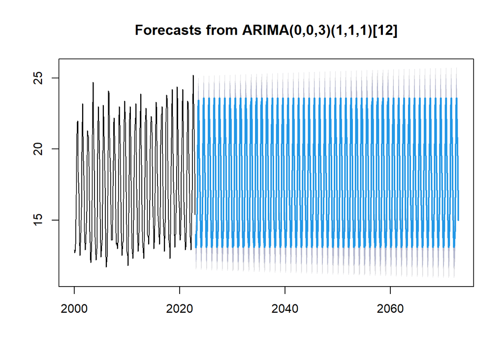

**Comment:** It seems that the prediction into the future for seawater temperatures using current temperatures and depth at 0 meters does not yield any significant trends. This result is most likely due to insufficient and inconsistent data. Each wave of the graph symbolizes one year, from the low peak temperature which happens during winter months (December, January, February) to the high peak of temperature which happens during summer months(July-August).

If we take a close look at the graph, we can see how from 2000 to around 2007ish the low peaks during winter months seem to get progressively lower. It’s not until 2010 onwards that the lower peaks seem to consistently increase in temperature. On the other hand, while the higher peaks seem to not have had any consistent downtrends, they haven’t had a consistent and strong upward trend either, remaining somewhat inconsistent and overall flat, with a bit of upward tendency.

In other words, it seems that the small upward tendency was not captured well by the model due to lack of data points as well as inconsistencies in the data. But what happens if we start aggregating the data on a year or depth basis?

**Example 1: Checking how well the model fits**

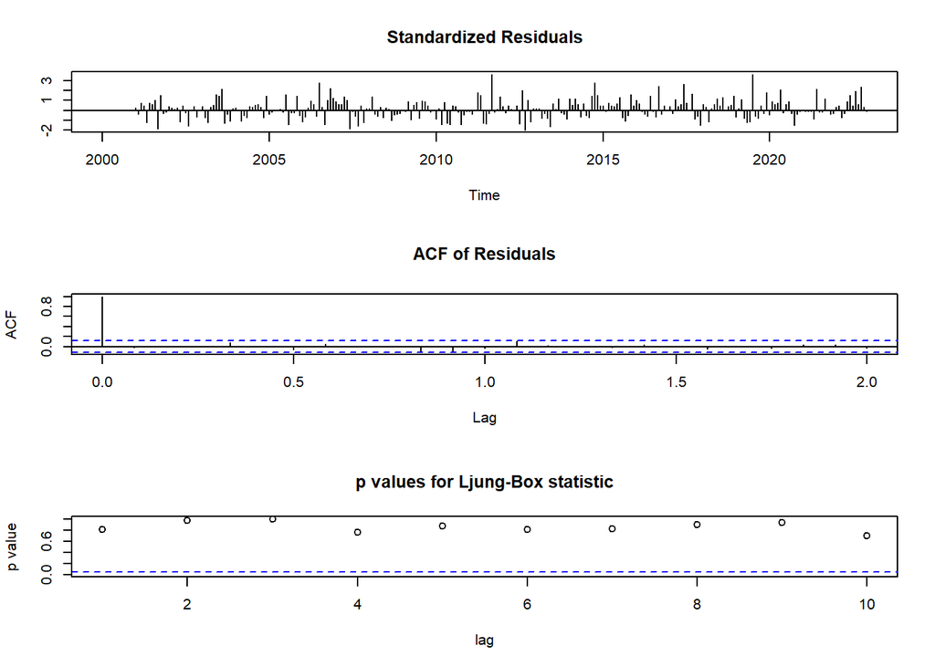

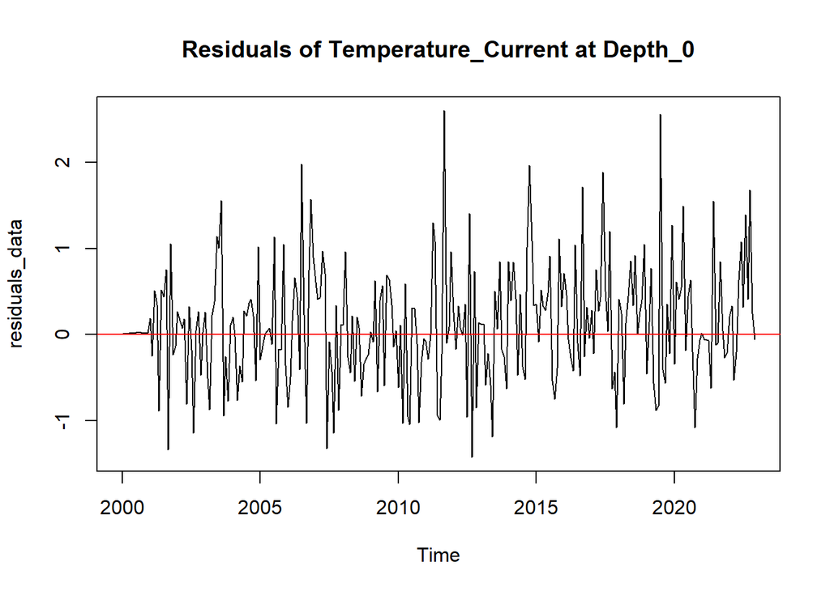

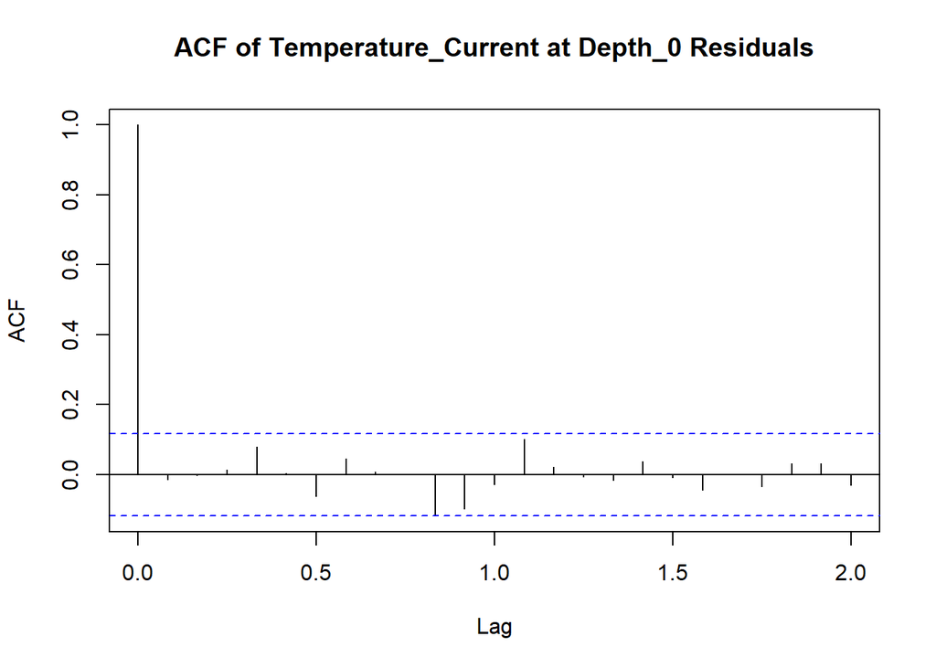

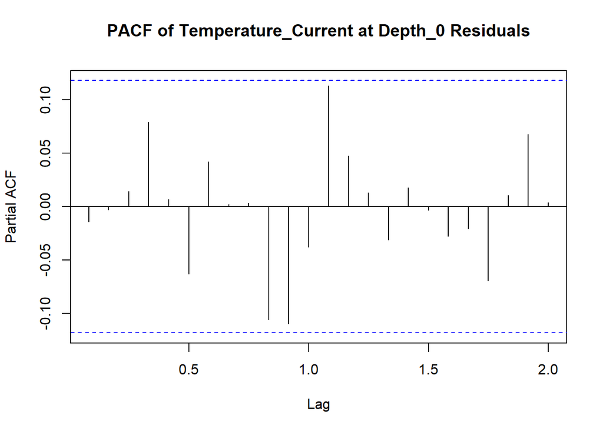

```
## [1] "Shapiro-Wilk Test for Temperature_Current at Depth_0 : p-value = 0.00049965053043909"
```

```r
perform_diagnostics(result_depth_0$model, result_depth_0$residuals, "Temperature_Current at Depth_0")
```

**Note: There is one spike of autocorrelation in the ACF graph that should warrant some attention. The Shappiro-Wilks test is significant, which means that the null hypothesis of normality is rejected. This also should warrant our attention, and some data transformation should be done to see if we can fit the model in a better way. However, due to the practical nature of this assignment, we think that this falls outside of what it is requested and thus we won’t be making any further modifications (in a real world case scenario it would be very different though).**

**Example 2: All depths, temperature difference**

```r
result_diff <- forecast_sarima(final_result1, "Temp_Diff_30yr")
```

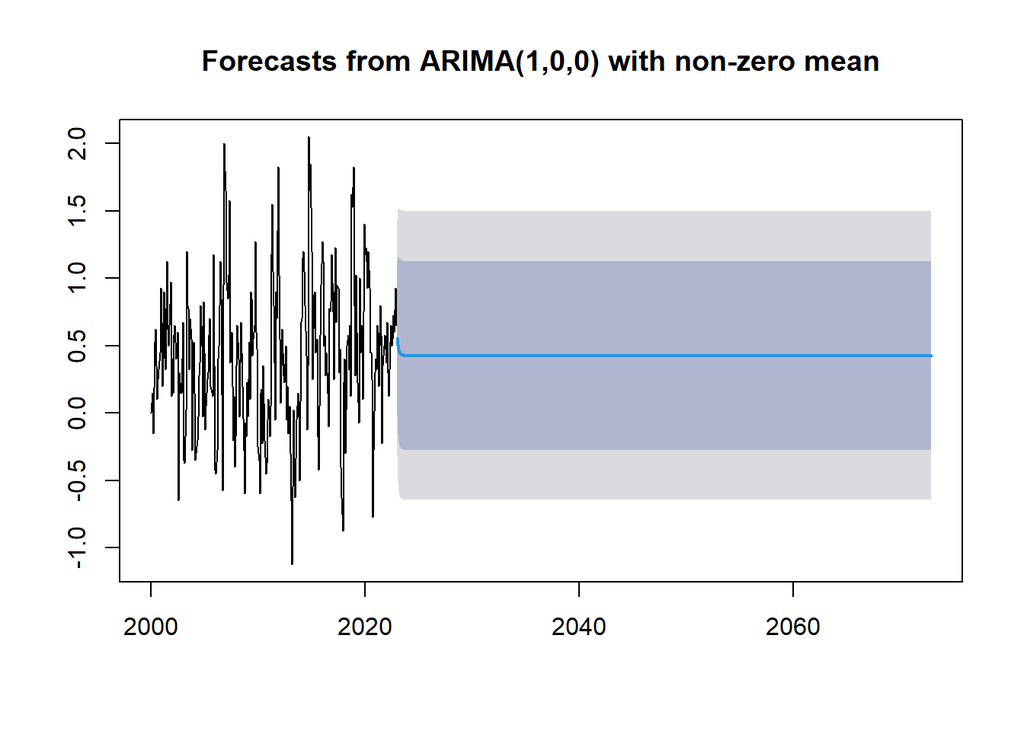

**Example 2: Checking how well the model fits**

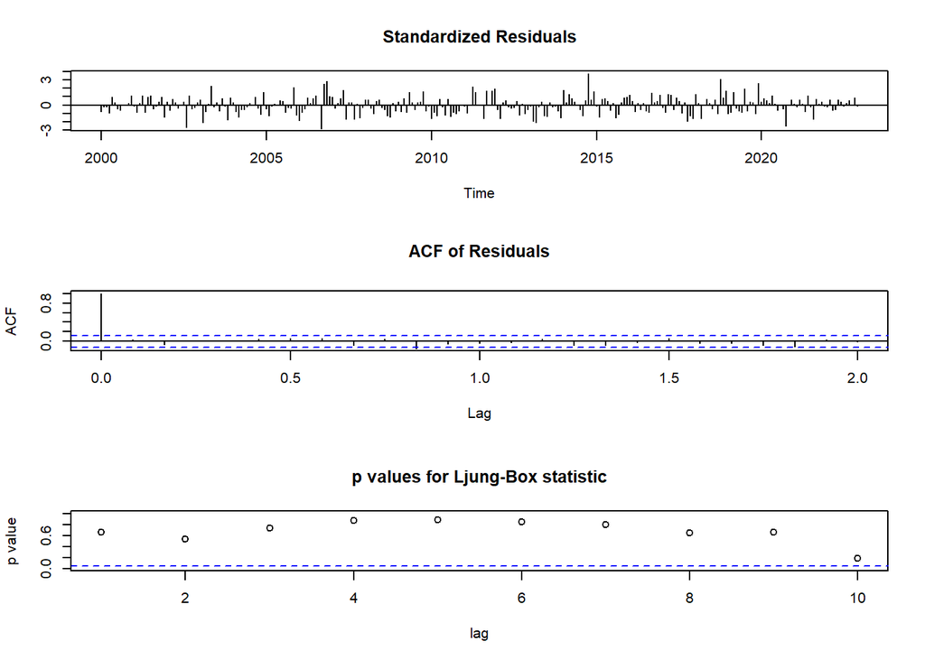

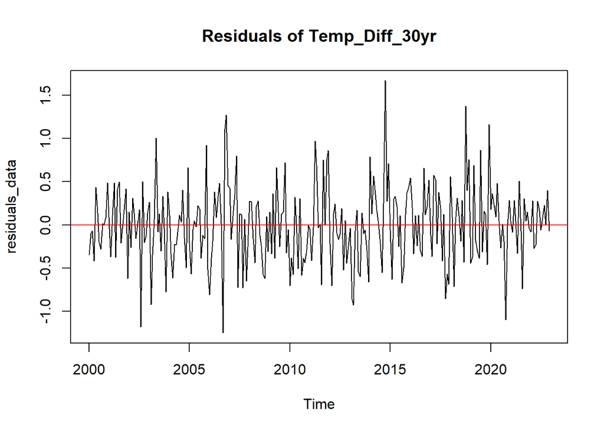

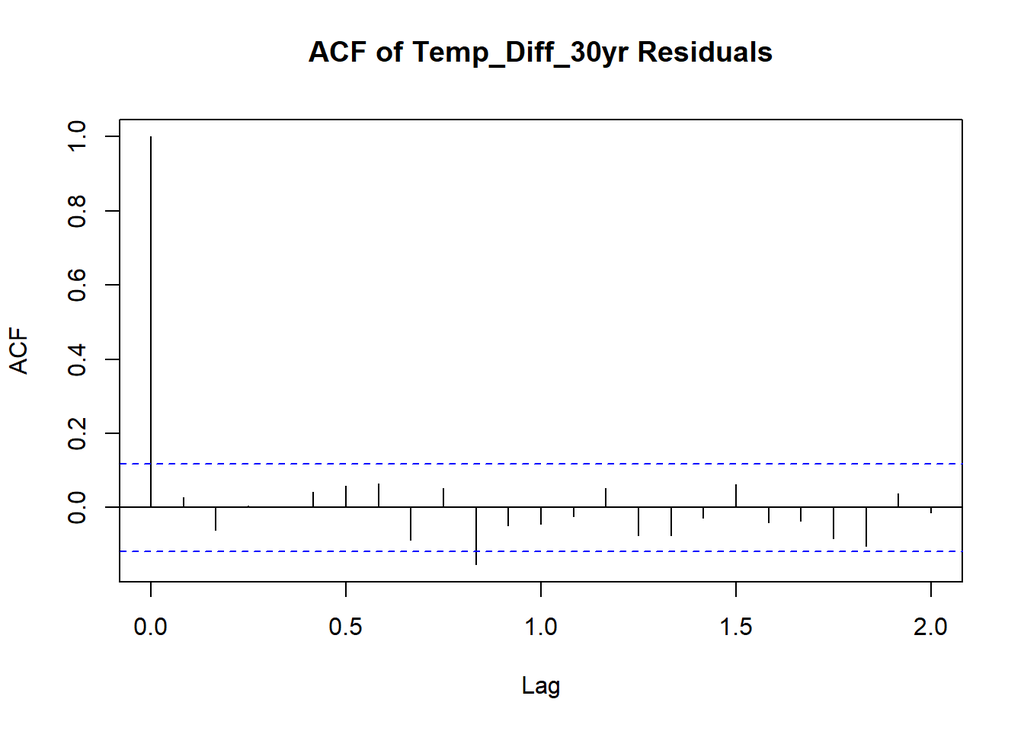

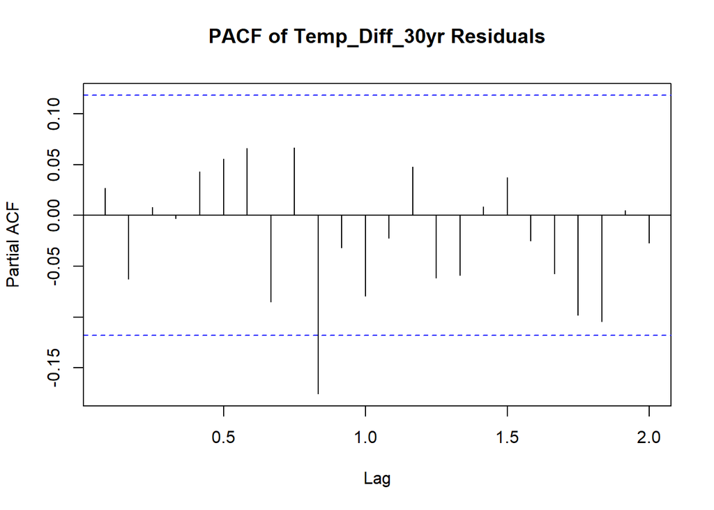

```
## [1] "Shapiro-Wilk Test for Temp_Diff_30yr : p-value = 0.0592269513618107"
```

```r
perform_diagnostics(result_diff$model, result_diff$residuals, "Temp_Diff_30yr")
```

**Note: There is one spike of autocorrelation in both the ACF and the PACF graphs that should warrant our attention.**

**Example 3: All depths, current temperature**

```r
result_current <- forecast_sarima(final_result1, "Temperature_Current")
```

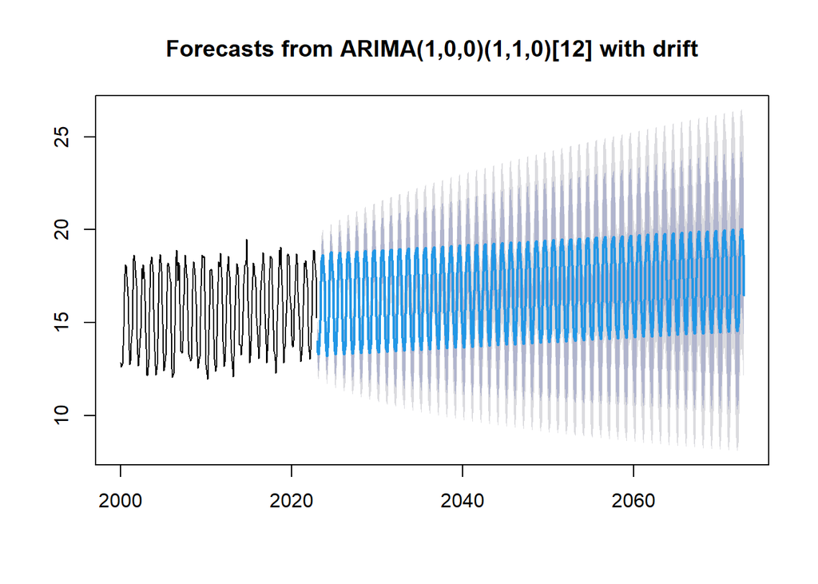

**Example 3: Checking how well the model fits**

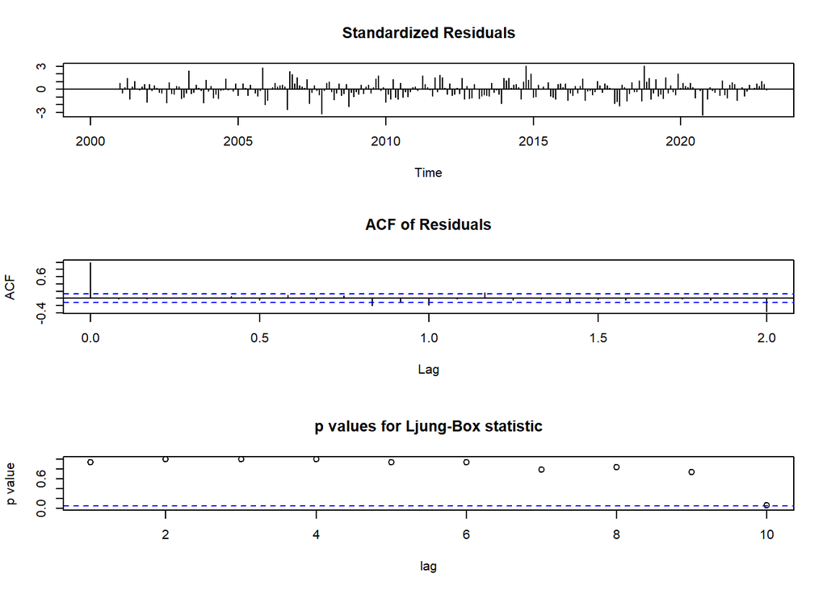

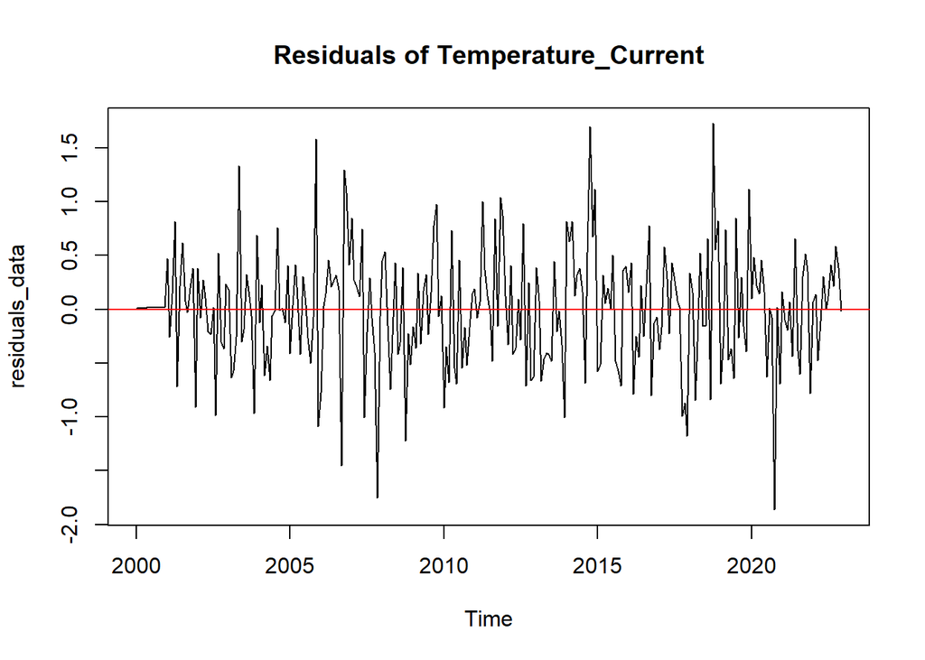

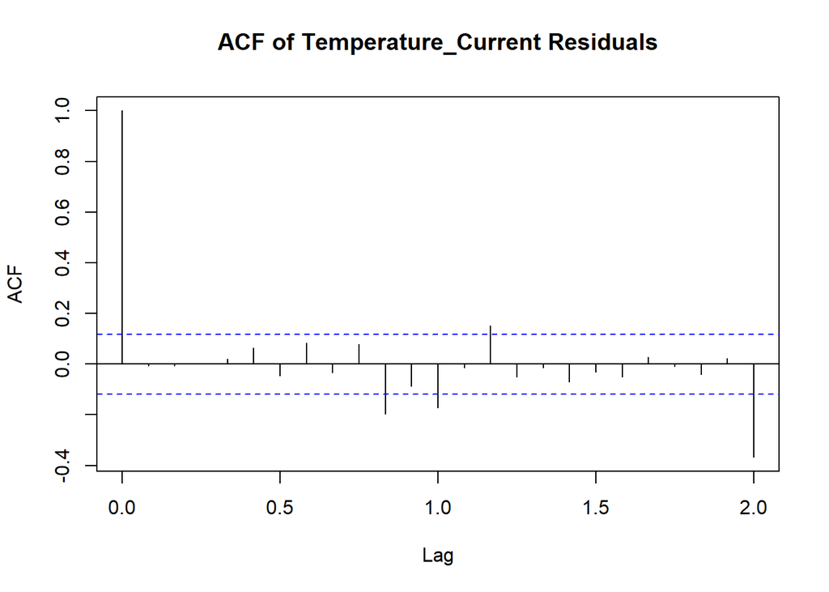

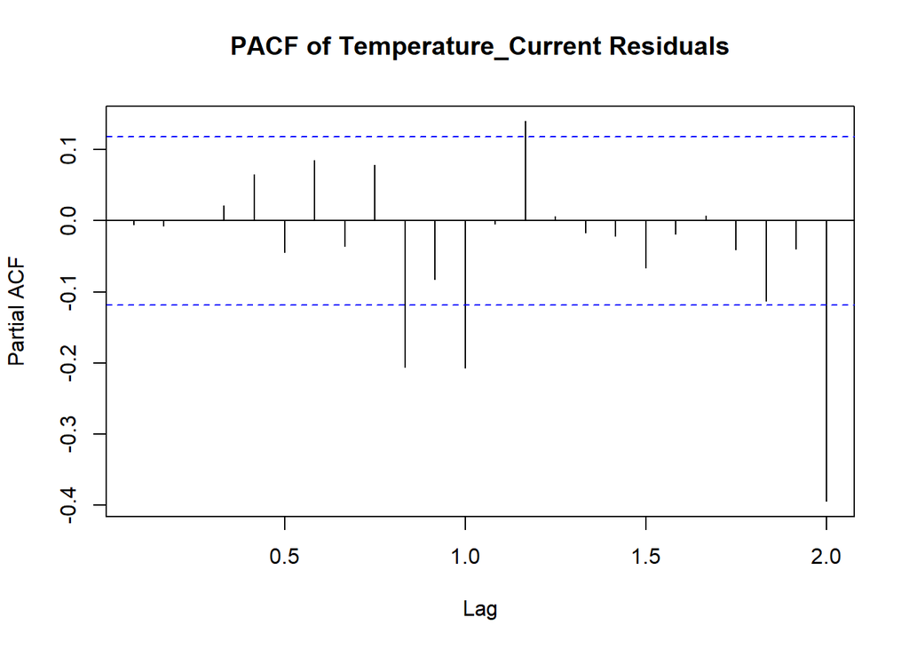

```
## [1] "Shapiro-Wilk Test for Temperature_Current : p-value = 0.079149979443115"
```

```r
perform_diagnostics(result_current$model, result_current$residuals, "Temperature_Current")
```

**Note: There is 2-3 spikes of autocorrelation in both the ACF and the PACF graphs that should warrant our attention. To fix this we would have to modify the MA(Moving Average) and AR (Autoregressive) terms of the model. However, this falls way out of what is requested in the exercise an what we have studied in the class as well as the purpose of this exercise, hence for the time being we will not be performing any aditional modifications to the model (we would have to manually tune the model instead of using the auto.arima() function and we lack the expertise in time series analysis, which is a second semester non mandatory subject we haven’t had the opportunity to study yet).**

**Example 4: All depths, historical temperature**

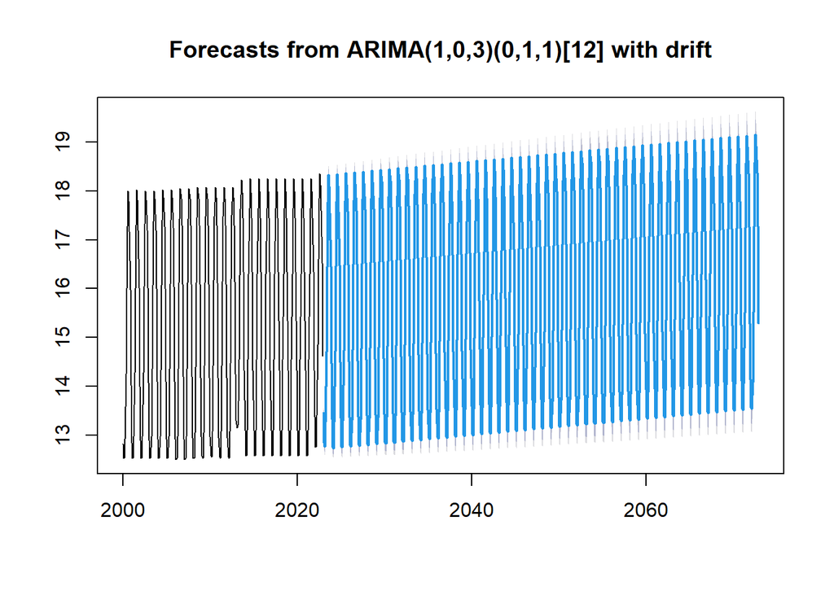

```r
result_historical <- forecast_sarima(final_result1, "Temperature_Historical")
```

**Comment:** This last forecast is the closest one to encompassing all available data we have in the dataset, taking the aggregate of all depths and the historical temperature as base for the predictions. As we can see, we get a beautiful graph that shows an upward tendency into the future with very low variation and very narrow confidence intervals.

**Example 4: Checking how well the model fits**

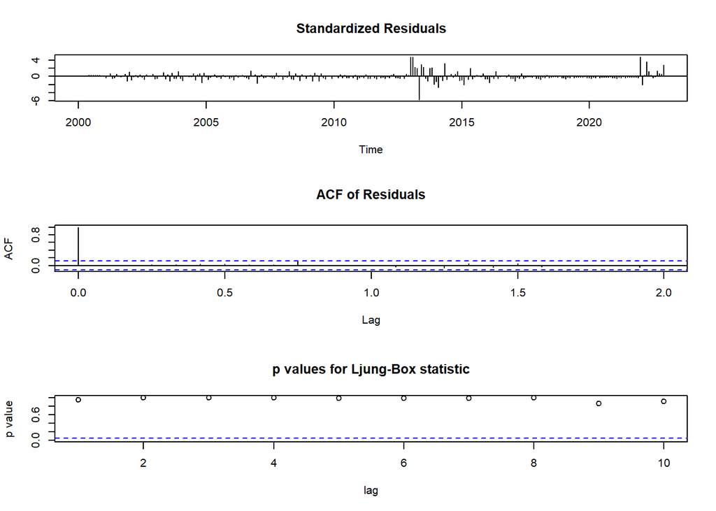

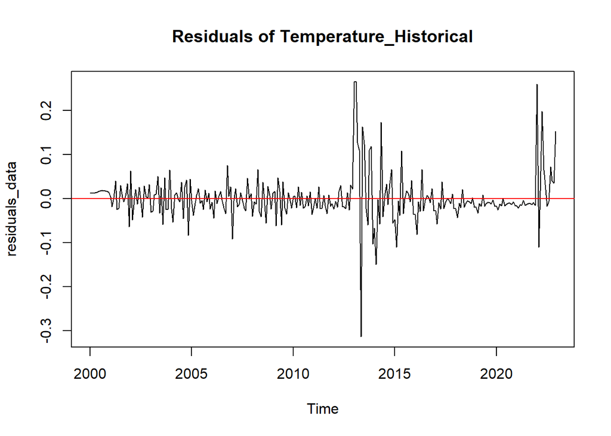

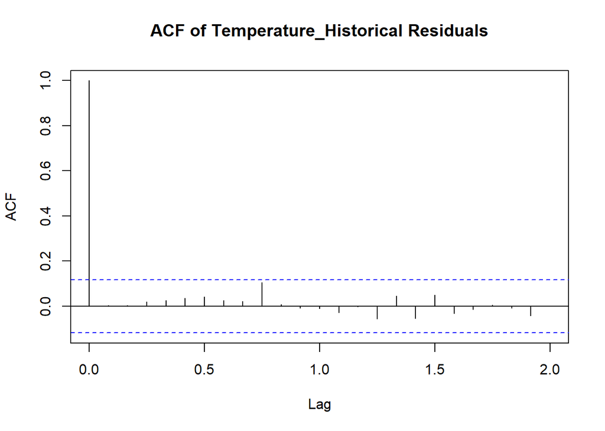

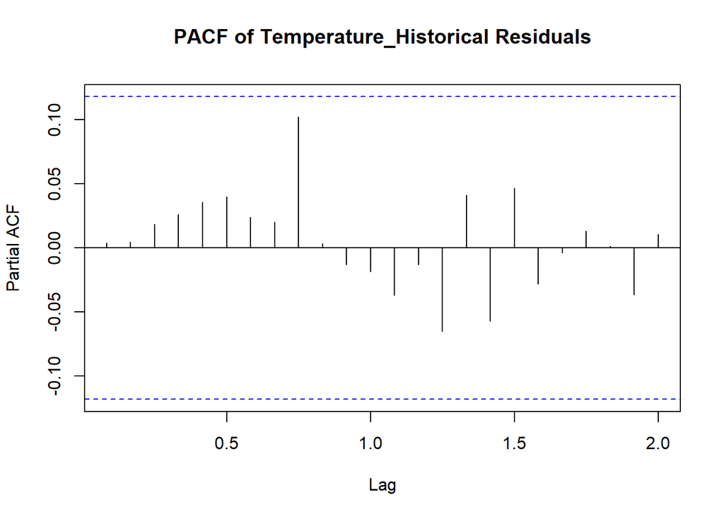

```
## [1] "Shapiro-Wilk Test for Temperature_Historical : p-value = 1.4491456476022e-18"
```

```r
perform_diagnostics(result_historical$model, result_historical$residuals, "Temperature_Historical")
```

Section E

Optionally, look for other data (public repositories, other sources), if you think it is necessary and cross them with those already available, especially if they help to better explain the possible climate change that is taking place

**Answer**

Since seawater and land-based temperatures are invariably closely linked, we think it will serve us well in confirming the upward trend in temperatures due to climate change. Without further ado:

```r
#Exercise 3e
analyzeTemperatureData <- function(country) {
  library(ggplot2)
  library(dplyr)
  library(car)
  library(tidyr)

  # Load the data
  url <- "https://raw.githubusercontent.com/gindeleo/climate/master/GlobalLandTemperaturesByCountry.csv"
  data <- read.csv(url, stringsAsFactors = FALSE)

  # Filter data for the specified country and years post-1752
  data_filtered <- data %>%
    filter(Country == country, !is.na(AverageTemperature)) %>%
    separate(col = dt, into = c("Year", "Month", "Day"), convert = TRUE) %>%
    filter(Year > 1752) %>%
    group_by(Year) %>%
    summarise(Temp = mean(AverageTemperature))

  p1 <- ggplot(data_filtered, aes(x = Year, y = Temp)) +
    geom_point(aes(colour = Temp)) +  # Use colour only for points
    geom_smooth() +  # No colour aesthetic here
    scale_color_gradient(low = "blue", high = "red") +
    ggtitle(paste(country, "'s Average Temperature 1753-2013")) +
    theme(plot.title = element_text(hjust = 0.5))

  print(p1)

  # Create intervals and plot boxplot
  min_year <- min(data_filtered$Year)
  max_year <- max(data_filtered$Year)
  total_years <- max_year - min_year + 1
  num_intervals <- 6
  interval_length <- floor(total_years / num_intervals)

  year_breaks <- c(min_year,
                   sapply(1:(num_intervals - 1), function(i) min_year + i * interval_length),
                   max_year + 1)

  interval_labels <- paste(head(year_breaks, -1), tail(year_breaks, -1) - 1, sep = "-")
  data_filtered$Interval <- cut(data_filtered$Year, breaks = year_breaks, labels = interval_labels, include.lowest = TRUE)


  p2 <- ggplot(data_filtered, aes(x = Interval, y = Temp)) +
    geom_boxplot(fill = "blue1") +
    ggtitle("Temperature Distribution Across Intervals") +
    theme(axis.text.x = element_text(angle = 45, hjust = 1), plot.title = element_text(hjust = 0.5))
  print(p2)

  # Conduct ANOVA
  anova_result <- aov(Temp ~ Interval, data = data_filtered)
  print(summary(anova_result))
  print(model.tables(anova_result, "means"), digits = 3)

  # Check ANOVA assumptions
  shapiro_res <- shapiro.test(residuals(anova_result))
  levene_res <- leveneTest(Temp ~ Interval, data = data_filtered)

  # Print results of assumption tests
  print(shapiro_res)
  print(levene_res)

  # If assumptions are violated, perform Welch's ANOVA and Games-Howell test
  if (shapiro_res$p.value < 0.05 || levene_res$'Pr(>F)'[1] < 0.05) {
    print("ANOVA assumptions violated. Proceeding with Welch's ANOVA and Games-Howell test.")
    welch_res <- oneway.test(Temp ~ Interval, data = data_filtered)
    print(welch_res)

    if (!requireNamespace("PMCMRplus", quietly = TRUE)) {
      install.packages("PMCMRplus")
    }
    library(PMCMRplus)
    gh_result <- gamesHowellTest(Temp ~ Interval, data = data_filtered)
    print(gh_result)
  } else {
    # Tukey HSD test if ANOVA assumptions are not violated
    tukey_res <- TukeyHSD(anova_result)
    print(tukey_res)
  }
}
```

The function analyzeTemperatureData() is designed to encapsulate various stages of data analysis, ranging from data retrieval and preprocessing to statistical analysis and visualization, thus offering a comprehensive insight into the temperature trends of a given country.

The function commences its operation by importing the global land temperature data by country from a predefined URL and loads it into a dataframe. This data is then meticulously filtered to focus on the chosen country, excluding entries with missing average temperature values. Furthermore, the function segregates the date into year, month, and day components and discards data preceding the year 1753 to ensure a consistent historical scope.

Upon preparing the data, the function proceeds to aggregate it by year, calculating the mean temperature for each year. This aggregated data is then utilized to generate two distinct types of visualizations. The first is a time series scatter plot, marked by a color gradient shifting from blue to red, representing cooler to warmer temperatures, respectively. This plot is enhanced with a smooth trend line, offering a clear visual depiction of the temporal changes in temperature. The second visualization is a boxplot segmented into dynamic time intervals, providing a graphical representation of the temperature distribution across these periods. This boxplot not only aids in visualizing the spread and central tendency of temperatures within each interval but also facilitates a comparative analysis across different time frames.

The analytical core of the function is the execution of an Analysis of Variance (ANOVA) to ascertain whether there are statistically significant differences in the mean temperatures across the defined intervals. The function outputs a detailed summary of the ANOVA, including mean temperatures for each interval. To ensure the validity of the ANOVA results, the script incorporates checks for normality and homogeneity of variances using the Shapiro-Wilk and Levene’s tests, respectively.

If these assumptions are not met, the function automatically adapts its analytical approach by employing Welch’s ANOVA and the Games-Howell post-hoc test, methods that are robust against assumption violations. Conversely, if the assumptions hold true, the script conducts the Tukey Honest Significant Difference (HSD) test, providing a thorough post-hoc analysis of interval differences.

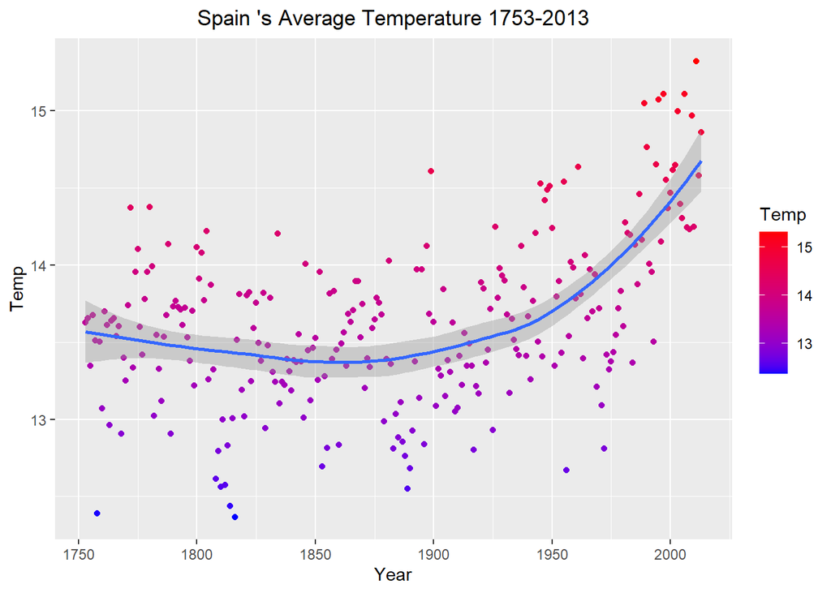

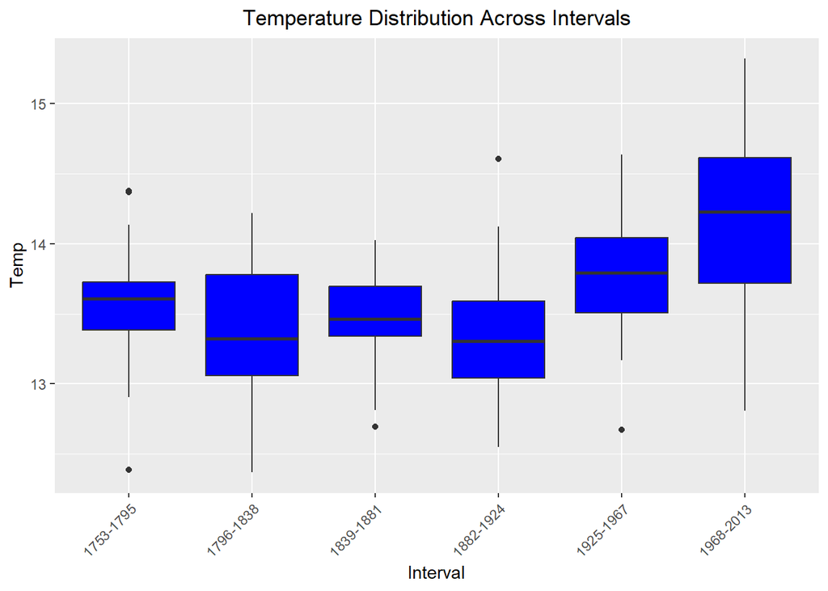

```
##              Df Sum Sq Mean Sq F value Pr(>F)
## Interval      5  23.31   4.662   22.64 <2e-16 ***
## Residuals   255  52.49   0.206
## ---
## Signif. codes:  0 '***' 0.001 '**' 0.01 '*' 0.05 '.' 0.1 ' ' 1
## Tables of means
## Grand mean
##
## 13.62374
##
##  Interval
##     1753-1795 1796-1838 1839-1881 1882-1924 1925-1967 1968-2013
##          13.6      13.4      13.5      13.3      13.8      14.2
## rep      44.0      43.0      43.0      43.0      43.0      45.0
##
##  Shapiro-Wilk normality test
##
## data:  residuals(anova_result)
## W = 0.99517, p-value = 0.5874
##
## Levene's Test for Homogeneity of Variance (center = median)
##        Df F value    Pr(>F)
## group   5  4.4917 0.0006103 ***
##       255
## ---
## Signif. codes:  0 '***' 0.001 '**' 0.01 '*' 0.05 '.' 0.1 ' ' 1
## [1] "ANOVA assumptions violated. Proceeding with Welch's ANOVA and Games-Howell test."
##
##  One-way analysis of means (not assuming equal variances)
##
## data:  Temp and Interval
## F = 16.443, num df = 5.00, denom df = 118.44, p-value = 2.656e-12
##
##           1753-1795 1796-1838 1839-1881 1882-1924 1925-1967
## 1796-1838 0.29434   -         -         -         -
## 1839-1881 0.85592   0.81447   -         -         -
## 1882-1924 0.07797   0.99769   0.42883   -         -
## 1925-1967 0.04155   0.00016   0.00068   7.9e-06   -
## 1968-2013 4.7e-06   1.6e-08   7.6e-08   1.1e-09   0.02639
```

```r
analyzeTemperatureData("Spain")
```

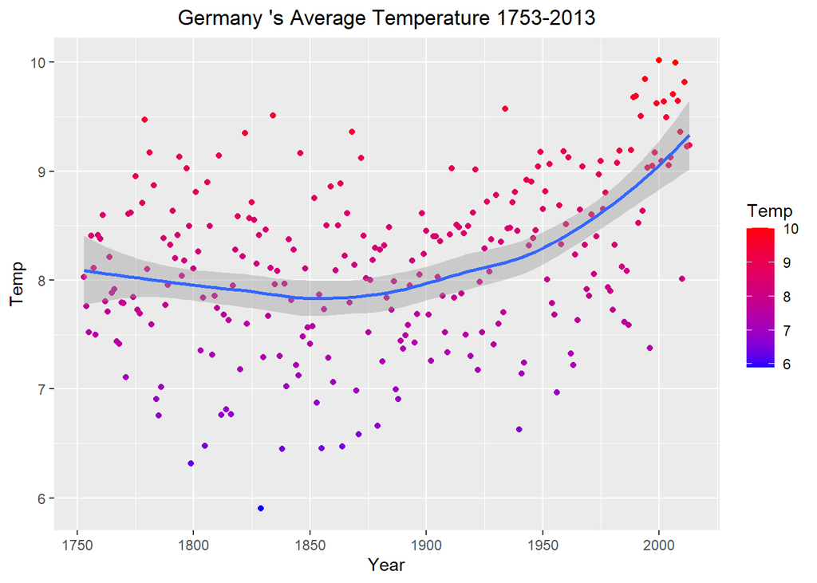

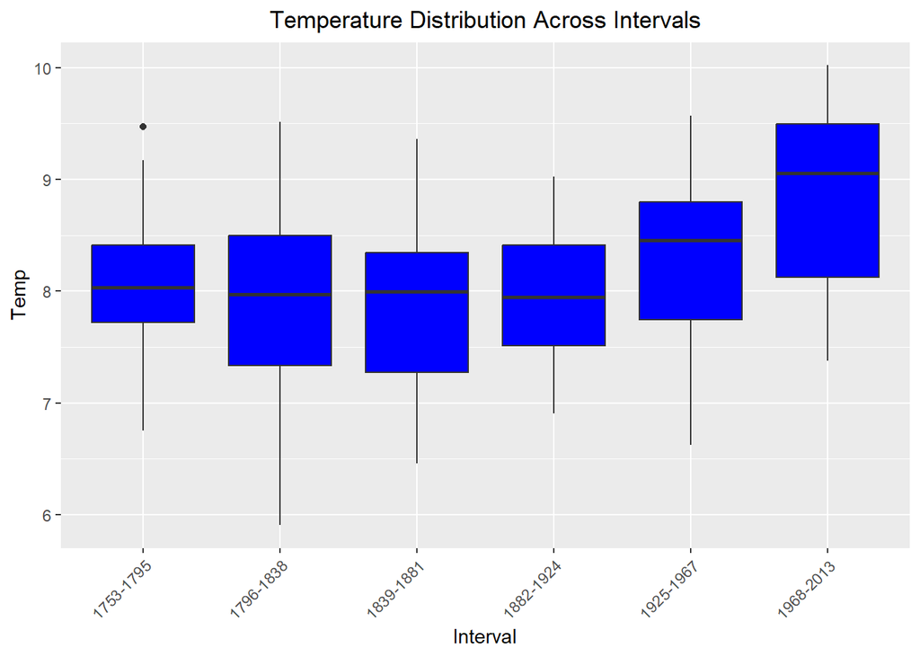

```
##              Df Sum Sq Mean Sq F value   Pr(>F)
## Interval      5  31.64   6.327   12.89 3.46e-11 ***
## Residuals   255 125.16   0.491
## ---
## Signif. codes:  0 '***' 0.001 '**' 0.01 '*' 0.05 '.' 0.1 ' ' 1
## Tables of means
## Grand mean
##
## 8.162492
##
##  Interval
##     1753-1795 1796-1838 1839-1881 1882-1924 1925-1967 1968-2013
##          8.06      7.91      7.87      7.95       8.3      8.86
## rep     44.00     43.00     43.00     43.00      43.0     45.00
##
##  Shapiro-Wilk normality test
##
## data:  residuals(anova_result)
## W = 0.98941, p-value = 0.05376
##
## Levene's Test for Homogeneity of Variance (center = median)
##        Df F value Pr(>F)
## group   5  1.7482 0.1241
##       255
##   Tukey multiple comparisons of means
##     95% family-wise confidence level
##
## Fit: aov(formula = Temp ~ Interval, data = data_filtered)
##
## $Interval
##                            diff         lwr       upr     p adj
## 1796-1838-1753-1795 -0.15633377 -0.58773123 0.2750637 0.9037493
## 1839-1881-1753-1795 -0.19892680 -0.63032426 0.2324707 0.7714406
## 1882-1924-1753-1795 -0.11707021 -0.54846767 0.3143273 0.9708266
## 1925-1967-1753-1795  0.23690847 -0.19448898 0.6683059 0.6145253
## 1968-2013-1753-1795  0.79438931  0.36786781 1.2209108 0.0000029
## 1839-1881-1796-1838 -0.04259302 -0.47646269 0.3912766 0.9997582
## 1882-1924-1796-1838  0.03926357 -0.39460611 0.4731332 0.9998379
## 1925-1967-1796-1838  0.39324225 -0.04062742 0.8271119 0.1003312
## 1968-2013-1796-1838  0.95072308  0.52170127 1.3797449 0.0000000
## 1882-1924-1839-1881  0.08185659 -0.35201308 0.5157263 0.9943742
## 1925-1967-1839-1881  0.43583527  0.00196560 0.8697049 0.0482407
## 1968-2013-1839-1881  0.99331611  0.56429429 1.4223379 0.0000000
## 1925-1967-1882-1924  0.35397868 -0.07989099 0.7878484 0.1810085
## 1968-2013-1882-1924  0.91145952  0.48243770 1.3404813 0.0000001
## 1968-2013-1925-1967  0.55748084  0.12845902 0.9865026 0.0031802
```

```r
analyzeTemperatureData("Germany")
```

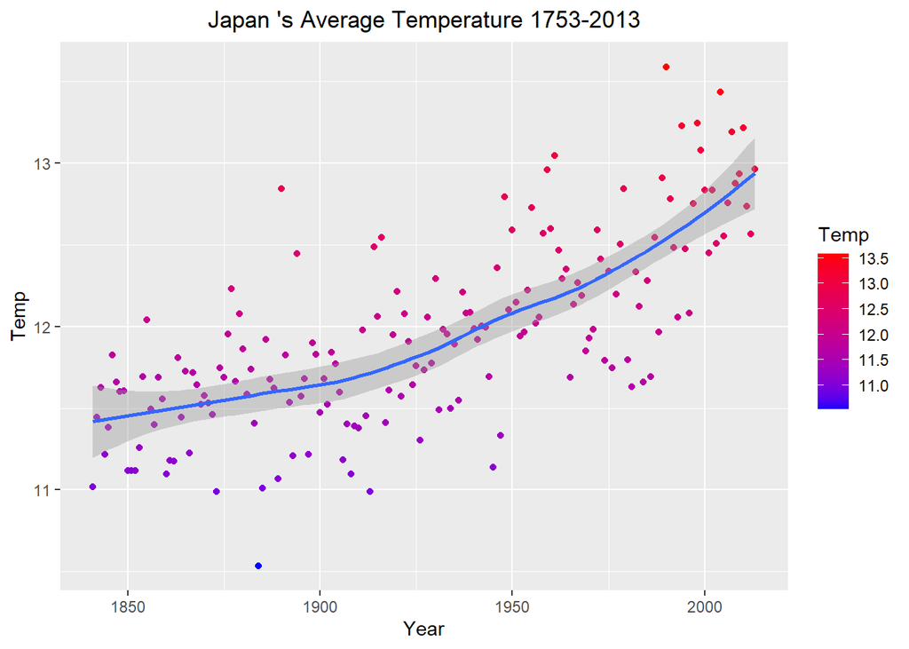

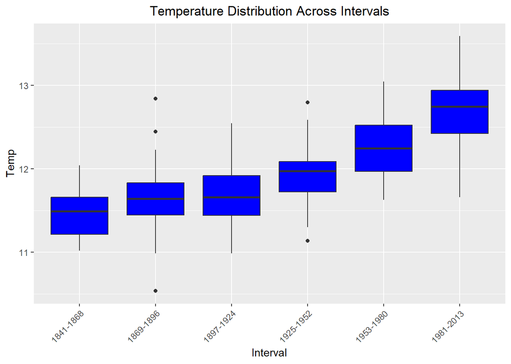

```
##              Df Sum Sq Mean Sq F value Pr(>F)
## Interval      5  30.29   6.057   38.16 <2e-16 ***
## Residuals   167  26.50   0.159
## ---
## Signif. codes:  0 '***' 0.001 '**' 0.01 '*' 0.05 '.' 0.1 ' ' 1
## Tables of means
## Grand mean
##
## 11.95386
##
##  Interval
##     1841-1868 1869-1896 1897-1924 1925-1952 1953-1980 1981-2013
##          11.5      11.6      11.7      11.9      12.3      12.7
## rep      29.0      28.0      28.0      28.0      28.0      32.0
##
##  Shapiro-Wilk normality test
##
## data:  residuals(anova_result)
## W = 0.99366, p-value = 0.6604
##
## Levene's Test for Homogeneity of Variance (center = median)
##        Df F value Pr(>F)
## group   5  1.2759 0.2766
##       167
##   Tukey multiple comparisons of means
##     95% family-wise confidence level
##
## Fit: aov(formula = Temp ~ Interval, data = data_filtered)
##
## $Interval
##                           diff         lwr       upr     p adj
## 1869-1896-1841-1868 0.16909021 -0.13522416 0.4734046 0.5984222
## 1897-1924-1841-1868 0.24272116 -0.06159321 0.5470355 0.2000833
## 1925-1952-1841-1868 0.46211402  0.15779965 0.7664284 0.0003003
## 1953-1980-1841-1868 0.79540866  0.49109429 1.0997230 0.0000000
## 1981-2013-1841-1868 1.19920591  0.90472715 1.4936847 0.0000000
## 1897-1924-1869-1896 0.07363095 -0.23334124 0.3806031 0.9826872
## 1925-1952-1869-1896 0.29302381 -0.01394838 0.5999960 0.0706312
## 1953-1980-1869-1896 0.62631845  0.31934626 0.9332906 0.0000003
## 1981-2013-1869-1896 1.03011570  0.73289115 1.3273402 0.0000000
## 1925-1952-1897-1924 0.21939286 -0.08757933 0.5263650 0.3132011
## 1953-1980-1897-1924 0.55268750  0.24571531 0.8596597 0.0000089
## 1981-2013-1897-1924 0.95648475  0.65926020 1.2537093 0.0000000
## 1953-1980-1925-1952 0.33329464  0.02632245 0.6402668 0.0247805
## 1981-2013-1925-1952 0.73709189  0.43986734 1.0343164 0.0000000
## 1981-2013-1953-1980 0.40379725  0.10657270 0.7010218 0.0017916
```

```r
analyzeTemperatureData("Japan")
```

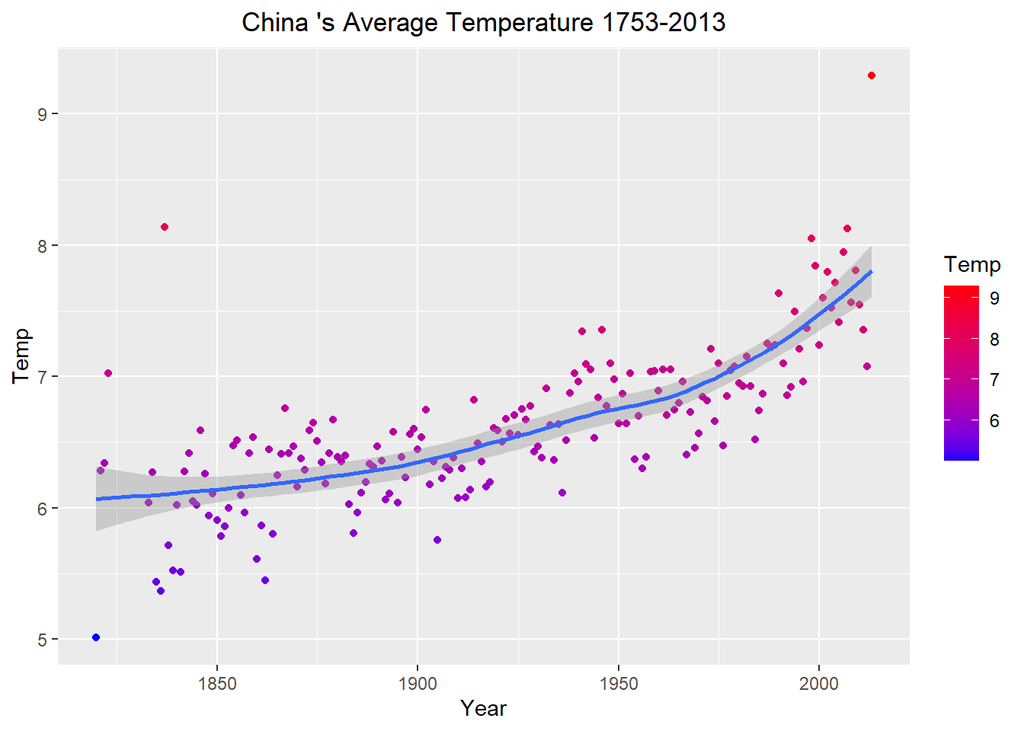

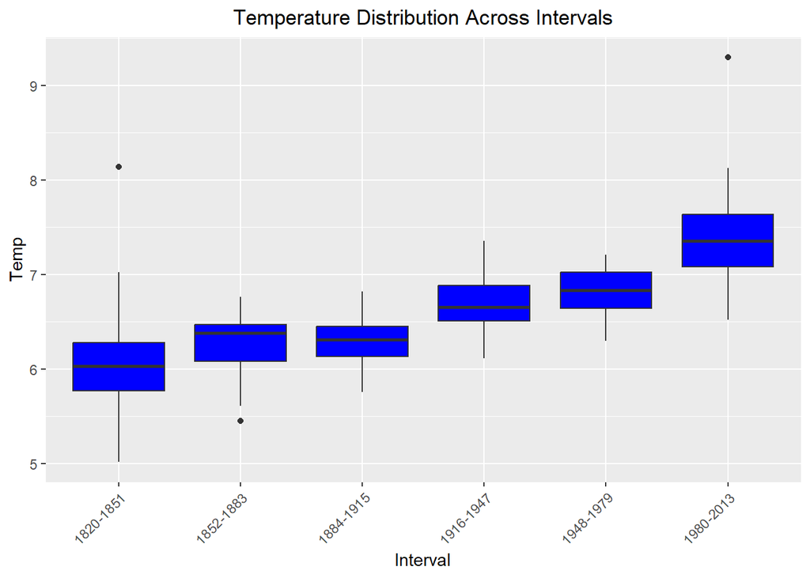

```
##              Df Sum Sq Mean Sq F value Pr(>F)
## Interval      5  35.51   7.101   47.02 <2e-16 ***
## Residuals   179  27.03   0.151
## ---
## Signif. codes:  0 '***' 0.001 '**' 0.01 '*' 0.05 '.' 0.1 ' ' 1
## Tables of means
## Grand mean
##
## 6.616264
##
##  Interval
##     1820-1851 1852-1883 1884-1915 1916-1947 1948-1979 1980-2013
##          6.08      6.27      6.31      6.69      6.79       7.4
## rep     24.00     32.00     32.00     32.00     32.00      33.0
##
##  Shapiro-Wilk normality test
##
## data:  residuals(anova_result)
## W = 0.91274, p-value = 5.137e-09
##
## Levene's Test for Homogeneity of Variance (center = median)
##        Df F value  Pr(>F)
## group   5  3.5866 0.00408 **
##       179
## ---
## Signif. codes:  0 '***' 0.001 '**' 0.01 '*' 0.05 '.' 0.1 ' ' 1
## [1] "ANOVA assumptions violated. Proceeding with Welch's ANOVA and Games-Howell test."
##
##  One-way analysis of means (not assuming equal variances)
##
## data:  Temp and Interval
## F = 38.982, num df = 5.000, denom df = 79.957, p-value < 2.2e-16
##
##           1820-1851 1852-1883 1884-1915 1916-1947 1948-1979
## 1852-1883 0.73679   -         -         -         -
## 1884-1915 0.53340   0.99457   -         -         -
## 1916-1947 0.00121   1.5e-05   7.2e-06   -         -
## 1948-1979 0.00013   8.5e-09   3.7e-10   0.70273   -
## 1980-2013 9.4e-10   < 2e-16   1.1e-12   2.0e-07   3.5e-06
```

```r
analyzeTemperatureData("China")
```

**Note: In all countries we have tried there is a very clear upward tendency of temperature. The p-values of all of the ANOVAs are below 0.05, and thus we can conclude that the difference in temperatures between intervals is statistically significant. We can also see the decomposition of this significant p-values between groups in the post-hoc analysis that the function realizes, which further confirms and reinforces the climate change thesis.**